# Week 8: Stochastic simulations

## Problem 2

Numerically integrate the $ \frac{\mathrm{d}m}{\mathrm{d}t} = \beta_m - \gamma_m m$ differential equation, using one of our previous methods (Euler, `scipy`, etc.). Plot the results of your numerical integration on top of your stochastic simulations from Problem 2. How do the results compare?

```python
def diffeq(m,t0, beta, gamma):
    # Compute dm/dt
    dm_dt =  beta - (gamma*m)

    # Return the result as a NumPy array
    return np.array(dm_dt)
```

```python
#numerical integration!!!!!
# Time points we want for the solution
t0 = np.linspace(0,10,1000)

# Initial conditions
mt_0 = np.array([1])

# Parameters
beta = 10
gamma = 1

# Package parameters into a tuple
args = (beta,gamma)

# Integrate ODES
mt = scipy.integrate.odeint(diffeq, mt_0, t0, args=(args))
```

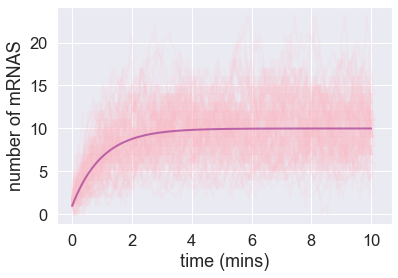

```python
#stochastic simulations from problem 2
for i in range(100):
    m = [1]
    t = [0]
    mRNApropdeg(t)
    plt.plot(t,m, alpha=.1, color = 'pink')
plt.plot(t0,mt, alpha=.5, color = 'purple')
plt.xlabel("time (mins)")
plt.ylabel("number of mRNAS")
```

## Problem 3

Expand our simulation from class to now keep track of both an mRNA and protein populations.

\begin{align} \begin{array}{ll} \text{reaction, }r_i & \text{propensity, } a_i \\ m \rightarrow m+1,\;\;\;\; & \beta_m \\[0.3em] m \rightarrow m-1, \;\;\;\; & \gamma_m m\\[0.3em] p \rightarrow p+1, \;\;\;\; & \beta_p m \\[0.3em] p \rightarrow p-1, \;\;\;\; & \gamma_p p. \end{array} \end{align}

Below I specify the parameters you should use for this simulation. Since the number of mRNAs and the number of proteins are substantially different, plot their trajectories over time on separate plots.

```python
# specifying the parameters
beta_m = 10 # per min
gamma_m = 1 # per min, per transcript
beta_p = 10 # per min
gamma_p = 0.5 # per min, per protein


# how long we want run simulation for
total_time = 20 # mins

m = [1]
p = [1]
t1 = [0]
```

```python
while t1[-1] < total_time:
        # specify the propensities for the possible state change
        production_prop = beta_m
        degradation_prop = gamma_m * m[-1]

        # specify the new propensities for the new possible state change
        production_prop0 = beta_p * m[-1]
        degradation_prop0 = gamma_p * p[-1]

        # add up all the propensities with the new propensities
        total_prop = production_prop + degradation_prop + production_prop0 + degradation_prop0

        # determine how much time elapses before "something+ happens
        time_elapsed= np.random.exponential(1/total_prop)

        # update time array
        t1.append(t1[-1] + time_elapsed)

        # randomly choose which event happens. weighted by their propensities
        event = random.choices(["production", "degradation", "production new", "degradation new"], weights=(production_prop, degradation_prop, production_prop0, degradation_prop0))[0]

        # update mRNA list based on which event happend
        if event == "production":
            m.append( m[-1] + 1 )
            #making sure everrything is the same length
            p.append(p[-1])

        if event == "degradation":
            m.append( m[-1] -1 )
            p.append(p[-1])
        # new chunk of updating mRNA list based on what event is happening
        if event == "production new":
            p.append( p[-1] + 1 )
            m.append(m[-1])

        if event == "degradation new":
            p.append( p[-1] -1 )
            m.append(m[-1])
```

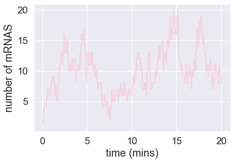

```python
plt.plot(t1,m, alpha=.5, color = 'pink')
plt.xlabel("time (mins)")
plt.ylabel("number of mRNAS")
```

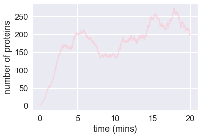

```python
plt.plot(t1,p, alpha=.5, color = 'pink')
plt.xlabel("time (mins)")
plt.ylabel("number of proteins")
```

## Problem 4

Returning to the original equations, what are the expected steady-state / fixed point values for the number of mRNAs and proteins? Calculate precise numbers based on the parameter values we've used here. How do these expected value compare to what you see in your simulation?

$$ \frac{\mathrm{d}m}{\mathrm{d}t} = \beta_m - \gamma_m m,$$$$ \frac{\mathrm{d}p}{\mathrm{d}t} = \beta_p m - \gamma_p p.$$

$ \frac{\beta_m}{\gamma_m} = m$

$ \frac{10}{1} = m$

$ 10 = m$

If we have beta as 10 and gamma as 1, we can conclude m= 10.

$ 0 = \beta_p (\frac{\beta_m}{\gamma_m}) - \gamma_p p.$

$ -\beta_p (\frac{\beta_m}{\gamma_m}) = - \gamma_p p.$

$ (\frac{\beta_p}{\gamma_p})(\frac{\beta_m}{\gamma_m}) = p.$

$ (\frac{\beta_p}{\gamma_p})(10) = p.$

$ (\frac{10}{.5})(10) = p.$

$ (20)(10) = p.$

$ 200= p.$

If we have beta as 10 and gamma as 0.5, we can conclude p = 200.

This relates to my code in the problem above because our average mRNA is around 10. In this problem, I recieved the answer of 10 for mRNA. I also received the answer of 200 for my proteins which relates to the previous problem's code because the proteins hang out around 200.

## Attribution

Materials for this notebook were borrowed from © 2019 [Justin Bois](http://bois.caltech.edu/teaching.html), as licensed under a Creative Commons Attribution License CC-BY 4.0. All code contained herein is licensed under an MIT license.